# CRQA Analysis

Fred Hasselman

2025-04-27

# Authors

**An Open-source Standardized Pipeline for Equitable Observations of Interactive Behavioral Dynamics: Theory-driven Measurement, Analysis, and Archiving**

Arkadiusz Białek<sup>1</sup>, Wim Pouw<sup>2</sup>, <sup>3</sup>, Travis J. Wiltshire<sup>2</sup>, James Trujillo<sup>4</sup>, Fred Hasselman<sup>5</sup>, Babajide Alamu Owoyele<sup>6</sup>, Natalia Siekiera<sup>1</sup> & Joanna Rączaszek-Leonardi<sup>7</sup>

1 Institute of Psychology, Jagiellonian University  
2 Department of Cognitive Science & Artificial Intelligence, Tilburg University  
3 Donders Institute for Brain, Cognition and Behaviour, Radboud University Nijmegen  
4 Institute for Logic, Language and Computation, University of Amsterdam  
5 Behavioural Science Institute, Radboud University Nijmegen  
6 Artificial Intelligence and Intelligent Systems, Hasso Plattner Institute Potsdam  
7 Human Interactivity and Language Lab, Faculty of Psychology, University of Warsaw

# Setup

Load some packages and set some variables… change the `path_repo` to the path where you downloaded the Github Repository (https://github.com/WimPouw/InterPerDynPipeline).

```r
# Load packages
library(rio)
library(plyr)
library(tidyverse)
library(casnet) # If you have not installed it: devtools::install_github("FredHasselman/casnet")
library(invctr)
library(fpCompare)
library(gplots)
library(testthat)
library(report)
library(emmeans)
library(sjPlot)


# Paths to files
path_repo <- "../"
path_meta <- file.path(path_repo,"meta")
path_oridata <- file.path(path_repo,"dataoutput_STEP1_2_timeseries")
path_results <- file.path(path_repo,"dataoutput_STEP3_nonlinearstatistics")
```

# Descriptive

Because the ages vary between measurement occasions, center ages on the mean of the first session.

```r
meta_data <- rio::import(file.path(path_meta,"project_point_metadata_ages.csv"))
crqa_data <- rio::import(file.path(path_results, "crqa_results_all.csv"))

# Figures CRQA ----

# Ages and sessions
brk <- round(colMeans(meta_data[,3:9], na.rm = TRUE),1)
lbls <- paste0("S",1:7,"=",brk)

crqa_data |>
  group_by(gender_f) |>
  summarise(mean = mean(age_days, na.rm = TRUE))
```

```
> # A tibble: 2 × 2
>   gender_f  mean
>   <chr>    <dbl>
> 1 boys      318.
> 2 girls     336.
```

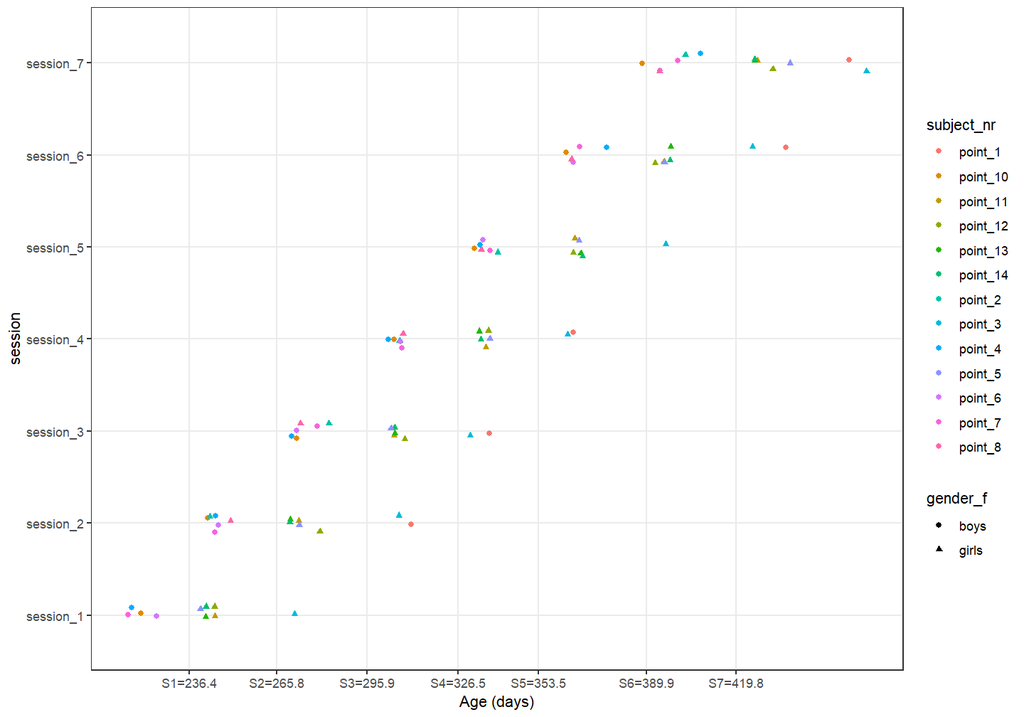

```r
ggplot(crqa_data, aes(x = age_days, y = session, group = subject_nr_n)) +
  geom_point(aes(colour = subject_nr, shape = gender_f),position = position_jitter(.4,.1)) +
  scale_x_continuous("Age (days)",breaks = brk, labels = lbls) +
  theme_bw() +
  theme(panel.grid.minor.x = element_blank())
```

Explore if there are any trends in the data for *DET*erminism.

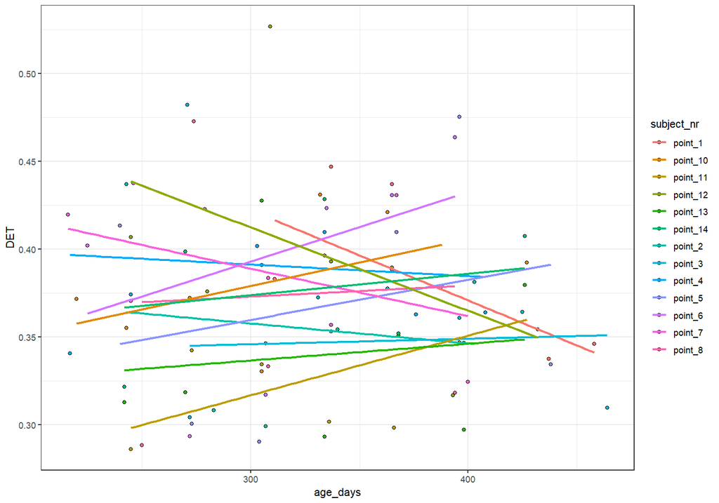

```r
# Linear
ggplot(crqa_data, aes(x = age_days, y = DET, group = subject_nr_n)) +
  geom_point(aes(fill = subject_nr), pch= 21) +
  geom_smooth(aes(colour = subject_nr), method = "lm", se = FALSE) +
  theme_bw()
```

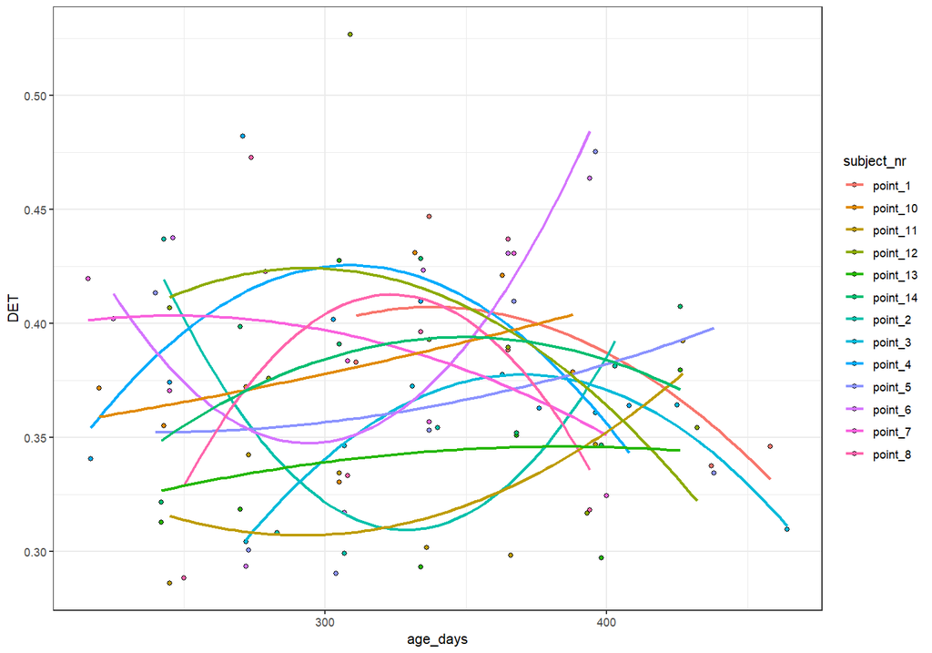

```r
# Square
ggplot(crqa_data, aes(x = age_days, y = DET, group = subject_nr_n)) +
  geom_point(aes(fill = subject_nr), pch= 21) +
  geom_smooth(aes(colour = subject_nr), method = "lm", formula = "y ~ poly(x, 2)", se = FALSE) +
  theme_bw()
```

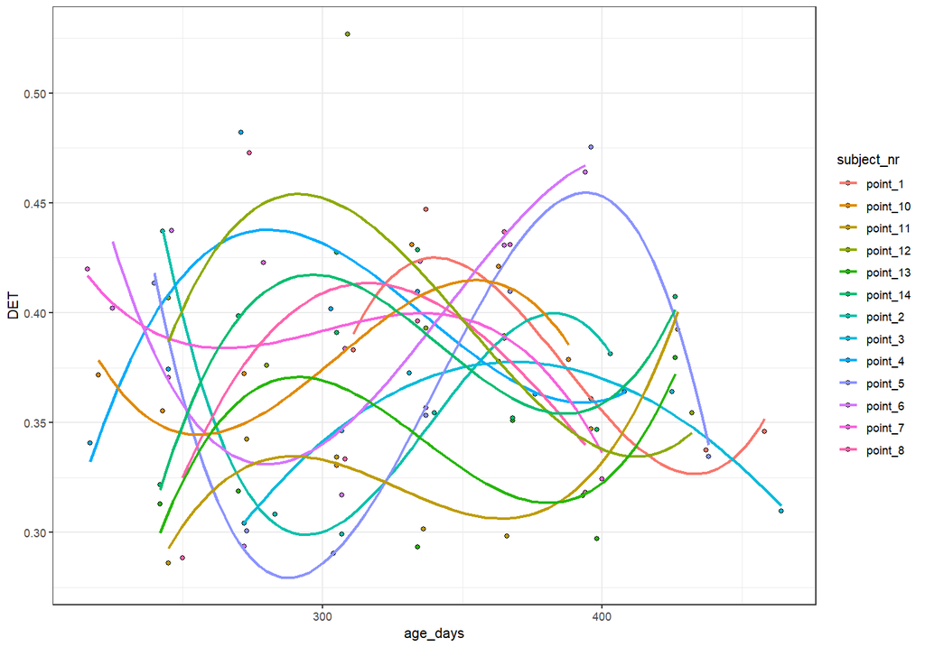

```r
# Cube
ggplot(crqa_data, aes(x = age_days, y = DET, group = subject_nr_n)) +
  geom_point(aes(fill = subject_nr), pch= 21) +
  geom_smooth(aes(colour = subject_nr), method = "lm", formula = "y ~ poly(x, 3)", se = FALSE) +
  theme_bw()
```

Not very clear, but perhaps some quadratics going on….

# Mixed Models

Let’s try a few models:

```r
library(lme4)
library(lmerTest)
library(emmeans)
library(future)

maxAge <- max(crqa_data$age_days_cS1)
crqa_data$age_days_cS1_u <- crqa_data$age_days_cS1/maxAge

# Linear time >> Yes
g0.1 <- glmer(N_dlp/RP_N ~ poly(age_days_cS1,1) + (1|subject_nr_f), weights = RP_N, family = binomial,crqa_data)
summary(g0.1)
```

```
> Generalized linear mixed model fit by maximum likelihood (Laplace
>   Approximation) [glmerMod]
>  Family: binomial  ( logit )
> Formula: N_dlp/RP_N ~ poly(age_days_cS1, 1) + (1 | subject_nr_f)
>    Data: crqa_data
> Weights: RP_N
>
>       AIC       BIC    logLik  deviance  df.resid
> 1366543.2 1366550.5 -683268.6 1366537.2        83
>
> Scaled residuals:
>     Min      1Q  Median      3Q     Max
> -269.21  -94.30   -5.22   79.68  353.53
>
> Random effects:
>  Groups       Name        Variance Std.Dev.
>  subject_nr_f (Intercept) 0.008158 0.09032
> Number of obs: 86, groups:  subject_nr_f, 13
>
> Fixed effects:
>                       Estimate Std. Error z value Pr(>|z|)
> (Intercept)           -0.53092    0.02505  -21.19   <2e-16 ***
> poly(age_days_cS1, 1)  0.05261    0.00170   30.96   <2e-16 ***
> ---
> Signif. codes:  0 '***' 0.001 '**' 0.01 '*' 0.05 '.' 0.1 ' ' 1
>
> Correlation of Fixed Effects:
>             (Intr)
> ply(__S1,1) 0.000
```

```r
# Random slopes? >> No
g0.2 <- glmer(N_dlp/RP_N ~ poly(age_days_cS1,1) + (poly(age_days_cS1_u,1, raw = TRUE)|subject_nr_f), weights = RP_N, family = binomial,crqa_data)
summary(g0.2)
```

```
> Generalized linear mixed model fit by maximum likelihood (Laplace
>   Approximation) [glmerMod]
>  Family: binomial  ( logit )
> Formula: N_dlp/RP_N ~ poly(age_days_cS1, 1) + (poly(age_days_cS1_u, 1,
>     raw = TRUE) | subject_nr_f)
>    Data: crqa_data
> Weights: RP_N
>
>       AIC       BIC    logLik  deviance  df.resid
> 1209090.4 1209102.6 -604540.2 1209080.4        81
>
> Scaled residuals:
>      Min       1Q   Median       3Q      Max
> -236.146  -99.237    0.918   76.584  315.030
>
> Random effects:
>  Groups       Name                                Variance Std.Dev. Corr
>  subject_nr_f (Intercept)                         0.03240  0.1800
>               poly(age_days_cS1_u, 1, raw = TRUE) 0.07098  0.2664   -0.85
> Number of obs: 86, groups:  subject_nr_f, 13
>
> Fixed effects:
>                       Estimate Std. Error z value Pr(>|z|)
> (Intercept)           -0.52053    0.02922  -17.82   <2e-16 ***
> poly(age_days_cS1, 1)  0.01738    0.19232    0.09    0.928
> ---
> Signif. codes:  0 '***' 0.001 '**' 0.01 '*' 0.05 '.' 0.1 ' ' 1
>
> Correlation of Fixed Effects:
>             (Intr)
> ply(__S1,1) -0.420
```

```r
# Quadratic time trend >> Yes
g0.3 <- glmer(N_dlp/RP_N ~ poly(age_days_cS1,2) + (1|subject_nr_f), weights = RP_N, family = binomial,crqa_data)
summary(g0.3)
```

```
> Generalized linear mixed model fit by maximum likelihood (Laplace
>   Approximation) [glmerMod]
>  Family: binomial  ( logit )
> Formula: N_dlp/RP_N ~ poly(age_days_cS1, 2) + (1 | subject_nr_f)
>    Data: crqa_data
> Weights: RP_N
>
>       AIC       BIC    logLik  deviance  df.resid
> 1337461.1 1337470.9 -668726.6 1337453.1        82
>
> Scaled residuals:
>     Min      1Q  Median      3Q     Max
> -271.17  -90.36  -16.61   76.27  338.09
>
> Random effects:
>  Groups       Name        Variance Std.Dev.
>  subject_nr_f (Intercept) 0.008278 0.09098
> Number of obs: 86, groups:  subject_nr_f, 13
>
> Fixed effects:
>                         Estimate Std. Error z value Pr(>|z|)
> (Intercept)            -0.531151   0.025234  -21.05   <2e-16 ***
> poly(age_days_cS1, 2)1  0.043810   0.001705   25.69   <2e-16 ***
> poly(age_days_cS1, 2)2 -0.277254   0.001628 -170.31   <2e-16 ***
> ---
> Signif. codes:  0 '***' 0.001 '**' 0.01 '*' 0.05 '.' 0.1 ' ' 1
>
> Correlation of Fixed Effects:
>             (Intr) p(__S1,2)1
> pl(__S1,2)1 0.000
> pl(__S1,2)2 0.000  0.031
```

```r
anova(g0.1,g0.2,g0.3)
```

```
> Data: crqa_data
> Models:
> g0.1: N_dlp/RP_N ~ poly(age_days_cS1, 1) + (1 | subject_nr_f)
> g0.3: N_dlp/RP_N ~ poly(age_days_cS1, 2) + (1 | subject_nr_f)
> g0.2: N_dlp/RP_N ~ poly(age_days_cS1, 1) + (poly(age_days_cS1_u, 1, raw = TRUE) | subject_nr_f)
>      npar     AIC     BIC  logLik deviance  Chisq Df Pr(>Chisq)
> g0.1    3 1366543 1366551 -683269  1366537
> g0.3    4 1337461 1337471 -668727  1337453  29084  1  < 2.2e-16 ***
> g0.2    5 1209090 1209103 -604540  1209080 128373  1  < 2.2e-16 ***
> ---
> Signif. codes:  0 '***' 0.001 '**' 0.01 '*' 0.05 '.' 0.1 ' ' 1
```

Not a lot going on so it seems… perhaps we need to consider `gender`?

```r
# Add gender
g1.4 <- glmer(N_dlp/RP_N ~ gender_f + poly(age_days_cS1,2) + (1|subject_nr_f), weights = RP_N, family = binomial,crqa_data)
summary(g1.4)
```

```
> Generalized linear mixed model fit by maximum likelihood (Laplace
>   Approximation) [glmerMod]
>  Family: binomial  ( logit )
> Formula: N_dlp/RP_N ~ gender_f + poly(age_days_cS1, 2) + (1 | subject_nr_f)
>    Data: crqa_data
> Weights: RP_N
>
>       AIC       BIC    logLik  deviance  df.resid
> 1337456.4 1337468.7 -668723.2 1337446.4        81
>
> Scaled residuals:
>     Min      1Q  Median      3Q     Max
> -271.17  -90.36  -16.61   76.27  338.10
>
> Random effects:
>  Groups       Name        Variance Std.Dev.
>  subject_nr_f (Intercept) 0.004939 0.07028
> Number of obs: 86, groups:  subject_nr_f, 13
>
> Fixed effects:
>                         Estimate Std. Error  z value Pr(>|z|)
> (Intercept)            -0.458070   0.031434  -14.572  < 2e-16 ***
> gender_fgirls          -0.118757   0.040071   -2.964  0.00304 **
> poly(age_days_cS1, 2)1  0.043811   0.001705   25.694  < 2e-16 ***
> poly(age_days_cS1, 2)2 -0.277257   0.001628 -170.317  < 2e-16 ***
> ---
> Signif. codes:  0 '***' 0.001 '**' 0.01 '*' 0.05 '.' 0.1 ' ' 1
>
> Correlation of Fixed Effects:
>             (Intr) gndr_f p(__S1,2)1
> gendr_fgrls -0.784
> pl(__S1,2)1  0.001 -0.001
> pl(__S1,2)2 -0.001  0.001  0.031
```

```r
# Conditional change model
g1.5 <- glmer(N_dlp/RP_N ~ gender_f * poly(age_days_cS1,2) + (1|subject_nr_f),  weights = RP_N, family = binomial,crqa_data)
saveRDS(g1.5, file = file.path(path_results, "g5_glmer.rds"))
summary(g1.5)
```

```
> Generalized linear mixed model fit by maximum likelihood (Laplace
>   Approximation) [glmerMod]
>  Family: binomial  ( logit )
> Formula: N_dlp/RP_N ~ gender_f * poly(age_days_cS1, 2) + (1 | subject_nr_f)
>    Data: crqa_data
> Weights: RP_N
>
>       AIC       BIC    logLik  deviance  df.resid
> 1326142.8 1326160.0 -663064.4 1326128.8        79
>
> Scaled residuals:
>     Min      1Q  Median      3Q     Max
> -280.51  -89.39  -12.35   78.35  344.46
>
> Random effects:
>  Groups       Name        Variance Std.Dev.
>  subject_nr_f (Intercept) 0.004969 0.07049
> Number of obs: 86, groups:  subject_nr_f, 13
>
> Fixed effects:
>                                       Estimate Std. Error  z value Pr(>|z|)
> (Intercept)                          -0.459487   0.031527  -14.574  < 2e-16 ***
> gender_fgirls                        -0.117889   0.040190   -2.933  0.00335 **
> poly(age_days_cS1, 2)1               -0.195862   0.002905  -67.417  < 2e-16 ***
> poly(age_days_cS1, 2)2               -0.420558   0.002435 -172.690  < 2e-16 ***
> gender_fgirls:poly(age_days_cS1, 2)1  0.344725   0.003659   94.217  < 2e-16 ***
> gender_fgirls:poly(age_days_cS1, 2)2  0.198030   0.003386   58.481  < 2e-16 ***
> ---
> Signif. codes:  0 '***' 0.001 '**' 0.01 '*' 0.05 '.' 0.1 ' ' 1
>
> Correlation of Fixed Effects:
>              (Intr) gndr_f p(__S1,2)1 p(__S1,2)2 g_:(__S1,2)1
> gendr_fgrls  -0.784
> pl(__S1,2)1   0.001 -0.001
> pl(__S1,2)2   0.000  0.000  0.330
> g_:(__S1,2)1 -0.001  0.000 -0.794     -0.262
> g_:(__S1,2)2  0.000  0.000 -0.237     -0.719      0.100
> optimizer (Nelder_Mead) convergence code: 0 (OK)
> Model is nearly unidentifiable: very large eigenvalue
>  - Rescale variables?
```

```r
anova(g1.4,g1.5)
```

```
> Data: crqa_data
> Models:
> g1.4: N_dlp/RP_N ~ gender_f + poly(age_days_cS1, 2) + (1 | subject_nr_f)
> g1.5: N_dlp/RP_N ~ gender_f * poly(age_days_cS1, 2) + (1 | subject_nr_f)
>      npar     AIC     BIC  logLik deviance Chisq Df Pr(>Chisq)
> g1.4    5 1337456 1337469 -668723  1337446
> g1.5    7 1326143 1326160 -663064  1326129 11318  2  < 2.2e-16 ***
> ---
> Signif. codes:  0 '***' 0.001 '**' 0.01 '*' 0.05 '.' 0.1 ' ' 1
```

```r
crqa_data$predg15 <- predict(g1.5, type = "response")

crqa_data_tmp <- crqa_data %>% filter(subject_nr!="point_14")

# Conditional change model without "Father-Daughter" dyad
g1.6 <- glmer(N_dlp/RP_N ~ gender_f * poly(age_days_cS1,2) + (1|subject_nr_f),  weights = RP_N, family = binomial,crqa_data_tmp)
summary(g1.6)
```

```
> Generalized linear mixed model fit by maximum likelihood (Laplace
>   Approximation) [glmerMod]
>  Family: binomial  ( logit )
> Formula: N_dlp/RP_N ~ gender_f * poly(age_days_cS1, 2) + (1 | subject_nr_f)
>    Data: crqa_data_tmp
> Weights: RP_N
>
>       AIC       BIC    logLik  deviance  df.resid
> 1268196.2 1268212.8 -634091.1 1268182.2        72
>
> Scaled residuals:
>     Min      1Q  Median      3Q     Max
> -280.51  -88.33  -13.53   76.42  346.26
>
> Random effects:
>  Groups       Name        Variance Std.Dev.
>  subject_nr_f (Intercept) 0.004835 0.06953
> Number of obs: 79, groups:  subject_nr_f, 12
>
> Fixed effects:
>                                       Estimate Std. Error  z value Pr(>|z|)
> (Intercept)                          -0.459517   0.031096  -14.778  < 2e-16 ***
> gender_fgirls                        -0.128045   0.040714   -3.145  0.00166 **
> poly(age_days_cS1, 2)1               -0.186423   0.002786  -66.906  < 2e-16 ***
> poly(age_days_cS1, 2)2               -0.409754   0.002373 -172.690  < 2e-16 ***
> gender_fgirls:poly(age_days_cS1, 2)1  0.289841   0.003627   79.921  < 2e-16 ***
> gender_fgirls:poly(age_days_cS1, 2)2  0.249142   0.003400   73.285  < 2e-16 ***
> ---
> Signif. codes:  0 '***' 0.001 '**' 0.01 '*' 0.05 '.' 0.1 ' ' 1
>
> Correlation of Fixed Effects:
>              (Intr) gndr_f p(__S1,2)1 p(__S1,2)2 g_:(__S1,2)1
> gendr_fgrls  -0.764
> pl(__S1,2)1   0.001 -0.001
> pl(__S1,2)2   0.000  0.000  0.326
> g_:(__S1,2)1 -0.001  0.000 -0.768     -0.251
> g_:(__S1,2)2  0.000  0.000 -0.228     -0.698      0.069
> optimizer (Nelder_Mead) convergence code: 0 (OK)
> Model is nearly unidentifiable: very large eigenvalue
>  - Rescale variables?
```

```r
crqa_data$dyad <- paste("mother -",ifelse(crqa_data$gender_f=="boys", "son","daughter"))
crqa_data$dyad[crqa_data$subject_nr=="point_14"] <- "father - daughter"
crqa_data$dyad_fs <- factor(crqa_data$dyad, c("mother - daughter", "mother - son", "father - daughter"), c("m-d", "m-s", "f-d"))
crqa_data$dyad_fs <- reorder(crqa_data$dyad_fs, ref = "f-d")

# Conditional change model with dyad-caregiver categories
g1.7 <- glmer(N_dlp/RP_N ~ dyad_fs * poly(age_days_cS1,2) + (1|subject_nr_f),  weights = RP_N, family = binomial,crqa_data)
saveRDS(g1.7, file = file.path(path_results, "g7_glmer.rds"))
summary(g1.7)
```

```
> Generalized linear mixed model fit by maximum likelihood (Laplace
>   Approximation) [glmerMod]
>  Family: binomial  ( logit )
> Formula: N_dlp/RP_N ~ dyad_fs * poly(age_days_cS1, 2) + (1 | subject_nr_f)
>    Data: crqa_data
> Weights: RP_N
>
>       AIC       BIC    logLik  deviance  df.resid
> 1321051.6 1321076.2 -660515.8 1321031.6        76
>
> Scaled residuals:
>     Min      1Q  Median      3Q     Max
> -280.51  -90.66  -11.59   81.48  346.26
>
> Random effects:
>  Groups       Name        Variance Std.Dev.
>  subject_nr_f (Intercept) 0.004463 0.06681
> Number of obs: 86, groups:  subject_nr_f, 13
>
> Fixed effects:
>                                    Estimate Std. Error z value Pr(>|z|)
> (Intercept)                       -0.505268   0.066804  -7.563 3.93e-14 ***
> dyad_fsm-d                        -0.082123   0.071418  -1.150    0.250
> dyad_fsm-s                         0.045781   0.073179   0.626    0.532
> poly(age_days_cS1, 2)1             0.344826   0.005743  60.043  < 2e-16 ***
> poly(age_days_cS1, 2)2            -0.641974   0.007085 -90.609  < 2e-16 ***
> dyad_fsm-d:poly(age_days_cS1, 2)1 -0.237782   0.006230 -38.166  < 2e-16 ***
> dyad_fsm-s:poly(age_days_cS1, 2)1 -0.540688   0.006436 -84.010  < 2e-16 ***
> dyad_fsm-d:poly(age_days_cS1, 2)2  0.477127   0.007513  63.508  < 2e-16 ***
> dyad_fsm-s:poly(age_days_cS1, 2)2  0.221417   0.007492  29.554  < 2e-16 ***
> ---
> Signif. codes:  0 '***' 0.001 '**' 0.01 '*' 0.05 '.' 0.1 ' ' 1
>
> Correlation of Fixed Effects:
>                     (Intr) dyd_fsm-d dyd_fsm-s p(__S1,2)1 p(__S1,2)2
> dyad_fsm-d          -0.935
> dyad_fsm-s          -0.913  0.854
> pl(__S1,2)1         -0.001  0.001     0.001
> pl(__S1,2)2          0.001 -0.001    -0.001    -0.074
> dyd_fsm-d:(__S1,2)1  0.001 -0.001    -0.001    -0.922      0.068
> dyd_fsm-s:(__S1,2)1  0.001 -0.001    -0.001    -0.892      0.066
> dyd_fsm-d:(__S1,2)2 -0.001  0.001     0.001     0.069     -0.943
> dyd_fsm-s:(__S1,2)2 -0.001  0.001     0.001     0.070     -0.946
>                     dyd_fsm-d:(__S1,2)1 dyd_fsm-s:(__S1,2)1 dyd_fsm-d:(__S1,2)2
> dyad_fsm-d
> dyad_fsm-s
> pl(__S1,2)1
> pl(__S1,2)2
> dyd_fsm-d:(__S1,2)1
> dyd_fsm-s:(__S1,2)1  0.823
> dyd_fsm-d:(__S1,2)2 -0.093              -0.062
> dyd_fsm-s:(__S1,2)2 -0.064              -0.014               0.892
> optimizer (Nelder_Mead) convergence code: 0 (OK)
> Model is nearly unidentifiable: very large eigenvalue
>  - Rescale variables?
```

```r
emmeans::emmeans(g1.7, ~ dyad_fs|poly(age_days_cS1,2), type = "response")
```

```
> age_days_cS1 = 92.6:
>  dyad_fs  prob      SE  df asymp.LCL asymp.UCL
>  f-d     0.392 0.01593 Inf     0.362     0.424
>  m-d     0.361 0.00583 Inf     0.350     0.373
>  m-s     0.398 0.00716 Inf     0.384     0.412
>
> Confidence level used: 0.95
> Intervals are back-transformed from the logit scale
```

```r
crqa_data$predg17 <- predict(g1.7, type = "response")
```

## Results

We use `g1.7` as the preferred model. With the `father - daughter` dyad as a reference.

Plot the predicted results:

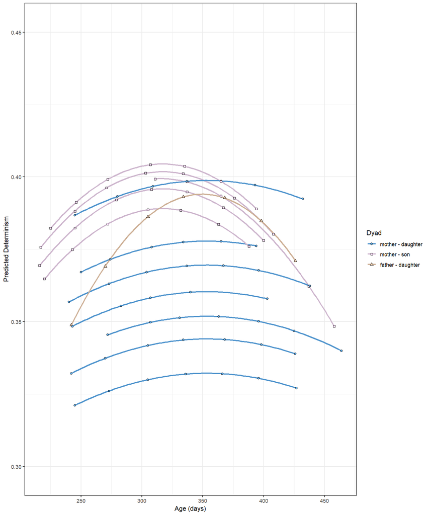

```r
crqa_data$dyad <- paste("mother -",ifelse(crqa_data$gender_f=="boys", "son","daughter"))
crqa_data$dyad[crqa_data$subject_nr=="point_14"] <- "father - daughter"
crqa_data$dyad_f <- factor(crqa_data$dyad, c("mother - daughter", "mother - son", "father - daughter"), ordered=TRUE)

ggplot(crqa_data, aes(x = age_days, y = predg17, group = subject_nr_f)) +
  geom_smooth(aes(colour = dyad_f), method = "lm", formula = "y ~ poly(x, 2)", se = FALSE) +
  geom_point(aes(shape = dyad_f, fill = dyad_f)) +
  scale_y_continuous("Predicted Determinism", limits = c(.3,.45), expand = c(0,.01)) +
  scale_x_continuous("Age (days)",c(250,300,350,400, 450)) +
  scale_fill_manual("Dyad", values = c("steelblue2","thistle2","peachpuff2")) +
  scale_colour_manual("Dyad", values = c("steelblue3","thistle3","peachpuff3")) +
  scale_shape_manual("Dyad", values = c(21,22,24)) +
  theme_bw()
```

```r
# save figure

ggsave(file.path(path_repo,"images/crqa_determinism_by_dyad.png"), width = 10, height = 7, dpi = 300)

# For the report we need the model fitted on the actual proportion, the form N_dlp/RP_N doesn't work
g1.7a <- glmer(DET ~ dyad_fs * poly(age_days_cS1_u,2, raw = TRUE) + (1|subject_nr_f),  weights = RP_N, family = binomial,crqa_data)
```

Fixed Effects for Generalized Linear Mixed Model Predicting N_dlp/RP_N

| effect | term | estimate | std.error | statistic | p.value | conf.low | conf.high |
| --- | --- | --- | --- | --- | --- | --- | --- |
| fixed | (Intercept) | -0.505 | 0.067 | -7.563 | 0.000 | -0.636 | -0.374 |
| fixed | dyad_fsm-d | -0.082 | 0.071 | -1.150 | 0.250 | -0.222 | 0.058 |
| fixed | dyad_fsm-s | 0.046 | 0.073 | 0.626 | 0.532 | -0.098 | 0.189 |
| fixed | poly(age_days_cS1, 2)1 | 0.345 | 0.006 | 60.043 | 0.000 | 0.334 | 0.356 |
| fixed | poly(age_days_cS1, 2)2 | -0.642 | 0.007 | -90.609 | 0.000 | -0.656 | -0.628 |
| fixed | dyad_fsm-d:poly(age_days_cS1, 2)1 | -0.238 | 0.006 | -38.166 | 0.000 | -0.250 | -0.226 |
| fixed | dyad_fsm-s:poly(age_days_cS1, 2)1 | -0.541 | 0.006 | -84.010 | 0.000 | -0.553 | -0.528 |
| fixed | dyad_fsm-d:poly(age_days_cS1, 2)2 | 0.477 | 0.008 | 63.508 | 0.000 | 0.462 | 0.492 |
| fixed | dyad_fsm-s:poly(age_days_cS1, 2)2 | 0.221 | 0.007 | 29.554 | 0.000 | 0.207 | 0.236 |

```
>
>
> **Random Effects:**
```

```
> - Subject (Intercept) SD: 0.067
```

```
> _ Model: binomial family with logit link. N = 86 observations, 13 dyads.
```

```
>
>
> **Model Summary (g1.7a):**
```

```
> - **Model type:** Generalized linear mixed model (binomial family with logit link)
```

```
> - **AIC:**  1321052
```

```
> - **BIC:**  1321076
```

```
> - **Log-likelihood:**  -660515.8
```

[output not shown]

```
> Both linear and quadratic age effects were significant, with significant interactions between dyad type and age trends.
```

```
> The father-daughter dyad serves as the reference category in the model.
```

[output not shown]